# Lab 10 - Space use and resource selection

```r
require(tidyverse)
require(terra)
require(tidyterra)
require(sf)
require(adehabitatHR)
require(adehabitatLT)
```

# Quick background

For this lab, we’re going to be using radiotelemetry data from Florida panthers (*Puma concolor coryi*) recorded in south Florida. The Florida panther is critically endangered, and there has been a push to understand space use, home ranges, and resource selection. After being collared with radio transmitters, individual panthers are relocated periodically (every 1-3 days) using airplanes. Most of the telemetry locations are recorded during the morning (7:00 am to 12:00 pm) which is a period of time when panthers are typically resting.

We’re going to be using data from 6 panthers, 3 of which are adults, and 3 of which are subadults. We’re going to first quantify utilization distributions for these cats, then we will contrast different approaches to understanding resource selection which vary in how they capture spatial and temporal scale.

# The data

First we are going to bring in a landcover raster. This landcover map has been aggregated at a 500 m resolution which reflects the approximate grain of telemetry error estimated in this study (489 m). This map was generated by the Florida Fish and Wildlife Commission and contains 43 landcover types, so we’re going to simplify it a bit.

```r
land = rast('https://github.com/ValenteJJ/SpatialEcology/raw/main/Week10/panther_landcover.tif')


classification = read.table('https://raw.githubusercontent.com/ValenteJJ/SpatialEcology/main/Week10/landcover%20reclass.txt', header=T)

head(classification)
```

|  | Landcover | Description | ChangeTo | Description2 |
| --- | --- | --- | --- | --- |
| 1 | 1 | CoastalStrand | 1 | coastalwetland |
| 2 | 2 | Sand | 1 | coastalwetland |
| 3 | 23 | saltmarsh | 1 | coastalwetland |
| 4 | 24 | mangroveswamp | 1 | coastalwetland |
| 5 | 25 | scrubmangrove | 1 | coastalwetland |
| 6 | 26 | tidalflat | 1 | coastalwetland |

```r
unique(classification$Description2)
```

```
##  [1] "coastalwetland"   "Cropland"         "OpenWater"        "PastureGrassland"
##  [5] "Urban"            "Barren"           "Dryprairie"       "Freshwatermarsh"
##  [9] "Scrub/Shrub"      "CypressSwamp"     "Pineland"         "HardwoodSwamp"
## [13] "UplandForest"     "Exotics"
```

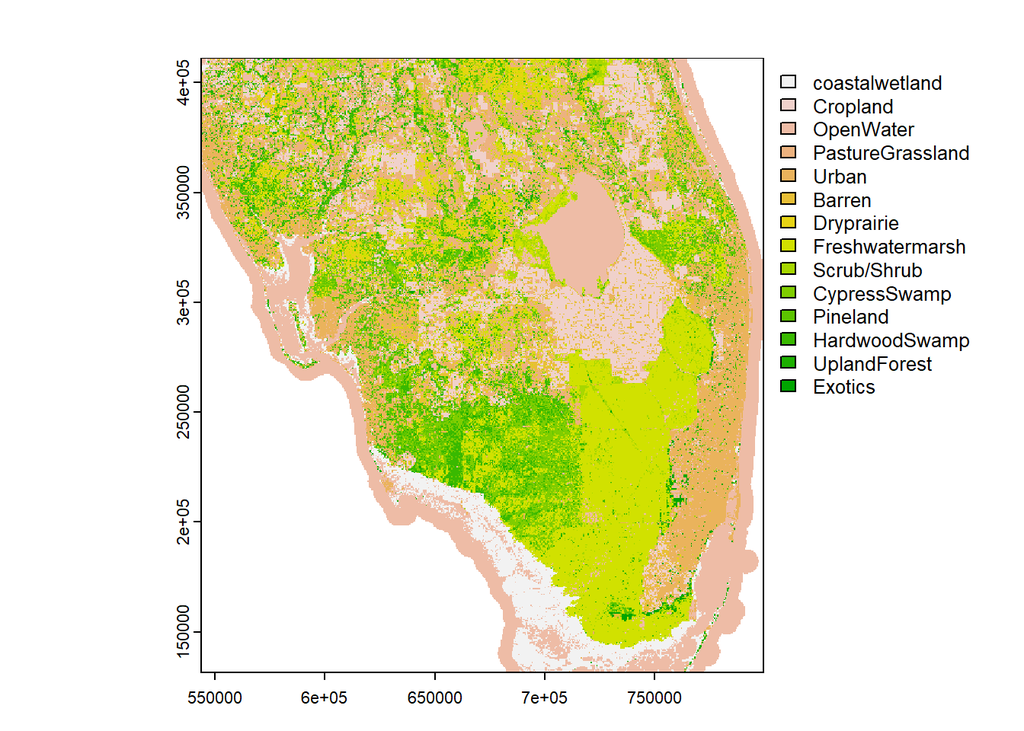

```r
land = classify(land, classification[,c(1,3)])
land = categories(land, value=unique(classification[,c(3,4)]))
plot(land)
```

Now we’re going to bring in the panther telemetry location data. Note that each observation has a X and Y coordinate, an ID for the individual animal, its age class, and a date on which the observation was recorded.

```r
panthers = st_read('/vsicurl/https://github.com/ValenteJJ/SpatialEcology/raw/main/Week10/panthers.shp') %>%
  mutate(CatID = as.factor(CatID))
summary(panthers)
```

```
##        X                Y           CatID        Juldate       AgeClass
##  Min.   :422801   Min.   :2866437   100:127   Min.   :6004   Length:713
##  1st Qu.:457742   1st Qu.:2900017   130: 85   1st Qu.:6093   Class :character
##  Median :470609   Median :2910316   131:118   Median :6186   Mode  :character
##  Mean   :474014   Mean   :2918828   137:131   Mean   :6182
##  3rd Qu.:490659   3rd Qu.:2932481   143:129   3rd Qu.:6268
##  Max.   :516770   Max.   :3042605   147:123   Max.   :6363
##           geometry
##  POINT        :713
##  epsg:NA      :  0
##  +proj=aea ...:  0
##
##
##
```

```r
unique(panthers$CatID)
```

```
## [1] 100 131 137 130 143 147
## Levels: 100 130 131 137 143 147
```

Note that the CRS for the raster and shapefile is the same, so we don’t have to do any spatial transformations. Therefore, we can just plot them on top of one another.

```r
crs(land, proj=T) == crs(panthers, proj=T)
```

```
## [1] TRUE
```

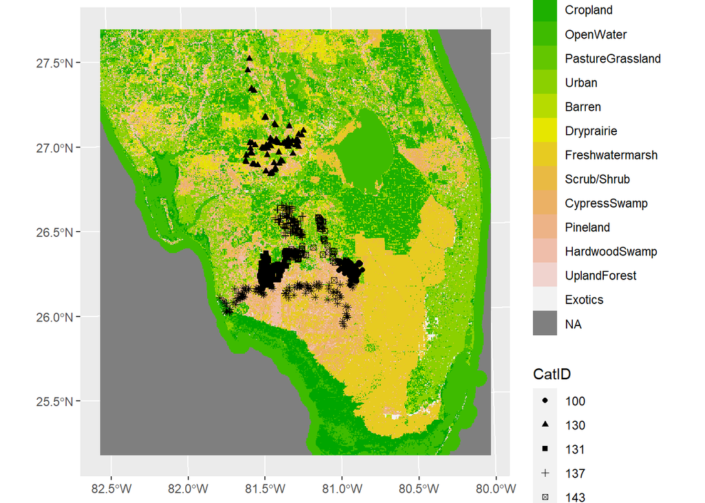

```r
ggplot()+
  geom_spatraster(data = land, aes(fill=Description2))+
  scale_fill_manual(values = terrain.colors(14))+
  geom_sf(data = panthers, aes(shape=CatID))
```

We’re also going to create layers that represent focal neighborhood summaries of upland and wetland forests which have been shown to be important for Florida panther resource selection. We’re going to calculate the proportion of each forest type within a 5 km radius which is a spatial scale that roughly reflects the median distance moved between successive points in this dataset.

```r
#Wet forest
wetForest = land
values(wetForest) = 0
wetForest[land %in% c(10,12)] = 1

probMatrix = focalMat(wetForest, 5000, type='circle', fillNA=FALSE)
wetFocal = focal(wetForest, probMatrix, fun='sum', na.rm=T)


#Dry forest
dryForest = land
values(dryForest) = 0
dryForest[land %in% c(11, 13)] = 1

probMatrix = focalMat(dryForest, 5000, type='circle', fillNA=FALSE)
dryFocal = focal(dryForest, probMatrix, fun='sum', na.rm=T)
```

Now we can stack these rasters up and visualize them.

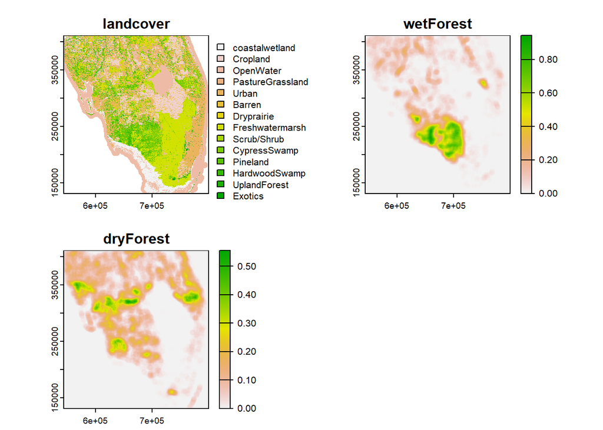

```r
layers = c(land, wetFocal, dryFocal)
names(layers) = c('landcover', 'wetForest', 'dryForest')
plot(layers)
```